# Practical Machine Learning course project. Prediction of the exercise execution manner

## Synopsis

Using devices such as Jawbone Up, Nike FuelBand, and Fitbit it is now possible to collect a large amount of data about personal activity.  
These type of devices are part of the quantified self movement. One thing that people regularly do is quantify how much of a particular activity they do, but they rarely quantify how well they do it.  
6 participants were asked to perform barbell lifts correctly and incorrectly in 5 different ways. The goal of the project - using the data from accelerometers on the belt, forearm, arm, and dumbbell predict, how well an exercise was doing. More information is available [here](http://groupware.les.inf.puc-rio.br/har) (Weight Lifting Exercises Dataset section).

## Input data and their processing

### Read data

The training data for this project have been downloaded locally from [here](https://d396qusza40orc.cloudfront.net/predmachlearn/pml-training.csv).  
We’re using the training data to train and test the model.  
The data set contain timestamps, user names, time window id and indication, sensor measurements and prediction class.

```r
library(caret)
data <- read.csv('pml-training.csv', na.strings = c("NA", "NaN", "", " ", "#DIV/0!"))
```

### Data clean-up

Inspecting training and [test data](https://d396qusza40orc.cloudfront.net/predmachlearn/pml-testing.csv) we see, there are variables (e.g. “kurtosis_…”, “max_…”, “min_…”, “amplitude_…”) that were calculated at the end of the time window only. We’ll not consider them since they appear relatively rare and do not appear in the test data set. We’ll use only sensor measurements (columns 8 - 159) and only data rows that do not have NAs

```r
temp <- data[,8:160] # use columns with measurements only
data <- temp[, colSums(!is.na(temp)) == nrow(temp)] #remove columns with NAs
```

Following columns remain:

```
##  [1] "roll_belt"            "pitch_belt"           "yaw_belt"
##  [4] "total_accel_belt"     "gyros_belt_x"         "gyros_belt_y"
##  [7] "gyros_belt_z"         "accel_belt_x"         "accel_belt_y"
## [10] "accel_belt_z"         "magnet_belt_x"        "magnet_belt_y"
## [13] "magnet_belt_z"        "roll_arm"             "pitch_arm"
## [16] "yaw_arm"              "total_accel_arm"      "gyros_arm_x"
## [19] "gyros_arm_y"          "gyros_arm_z"          "accel_arm_x"
## [22] "accel_arm_y"          "accel_arm_z"          "magnet_arm_x"
## [25] "magnet_arm_y"         "magnet_arm_z"         "roll_dumbbell"
## [28] "pitch_dumbbell"       "yaw_dumbbell"         "total_accel_dumbbell"
## [31] "gyros_dumbbell_x"     "gyros_dumbbell_y"     "gyros_dumbbell_z"
## [34] "accel_dumbbell_x"     "accel_dumbbell_y"     "accel_dumbbell_z"
## [37] "magnet_dumbbell_x"    "magnet_dumbbell_y"    "magnet_dumbbell_z"
## [40] "roll_forearm"         "pitch_forearm"        "yaw_forearm"
## [43] "total_accel_forearm"  "gyros_forearm_x"      "gyros_forearm_y"
## [46] "gyros_forearm_z"      "accel_forearm_x"      "accel_forearm_y"
## [49] "accel_forearm_z"      "magnet_forearm_x"     "magnet_forearm_y"
## [52] "magnet_forearm_z"     "classe"
```

### Slicing data

60% of the data are used for the training, 20% are used for model selection and 20% will be testing data.

```r
set.seed(12123) #to reproduce the results
train_idx <- createDataPartition(y = data$classe, p = 0.6, list = FALSE)
training <- data[train_idx,]
temp <- data[-train_idx,]
temp_idx <- createDataPartition(y = temp$classe, p = 0.5, list = FALSE)
testing <- temp[temp_idx,]
tuning <- temp[-temp_idx,]
```

## Model selection

Using our training data we evaluate random forest and boosting with tree.  
The default re-sampling scheme is the bootstrap. Instead we’re using 10-fold cross validation.

```r
train_ctrl <- trainControl(method = "cv", number = 10)
```

We’re using random forest with default settings.

```r
rf_mod <- train(classe~., data = training, method = "rf",
                trControl = train_ctrl, importance = TRUE,
                ntree = 500)
```

```r
gbmGrid <- expand.grid(.interaction.depth = 5,
                       .n.trees = 250, .shrinkage = .1)
gbm_mod <- train(classe~., data = training, method = "gbm",
                 trControl = train_ctrl, tuneGrid = gbmGrid,
                 verbose = FALSE)
```

We run the prediction on the tuning data to select the model

```r
rf_predict <- predict(rf_mod, tuning)
gbm_predict <- predict(gbm_mod, tuning)
```

Checking the confusion matrix on prediction…  
…for random forest

```
## Confusion Matrix and Statistics
##
##           Reference
## Prediction    A    B    C    D    E
##          A 1114    1    1    0    0
##          B    9  746    4    0    0
##          C    0    4  678    2    0
##          D    0    0    3  639    1
##          E    0    0    2    1  718
##
## Overall Statistics
##
##                Accuracy : 0.993
##                  95% CI : (0.99, 0.995)
##     No Information Rate : 0.286
##     P-Value [Acc > NIR] : <2e-16
##
##                   Kappa : 0.991
##  Mcnemar's Test P-Value : NA
##
## Statistics by Class:
##
##                      Class: A Class: B Class: C Class: D Class: E
## Sensitivity             0.992    0.993    0.985    0.995    0.999
## Specificity             0.999    0.996    0.998    0.999    0.999
## Pos Pred Value          0.998    0.983    0.991    0.994    0.996
## Neg Pred Value          0.997    0.998    0.997    0.999    1.000
## Prevalence              0.286    0.191    0.175    0.164    0.183
## Detection Rate          0.284    0.190    0.173    0.163    0.183
## Detection Prevalence    0.284    0.193    0.174    0.164    0.184
## Balanced Accuracy       0.996    0.995    0.992    0.997    0.999
```

… and for boosting

```
## Confusion Matrix and Statistics
##
##           Reference
## Prediction    A    B    C    D    E
##          A 1110    4    2    0    0
##          B    9  744    6    0    0
##          C    0    3  676    5    0
##          D    0    1    1  641    0
##          E    0    3    4    2  712
##
## Overall Statistics
##
##                Accuracy : 0.99
##                  95% CI : (0.986, 0.993)
##     No Information Rate : 0.285
##     P-Value [Acc > NIR] : <2e-16
##
##                   Kappa : 0.987
##  Mcnemar's Test P-Value : NA
##
## Statistics by Class:
##
##                      Class: A Class: B Class: C Class: D Class: E
## Sensitivity             0.992    0.985    0.981    0.989    1.000
## Specificity             0.998    0.995    0.998    0.999    0.997
## Pos Pred Value          0.995    0.980    0.988    0.997    0.988
## Neg Pred Value          0.997    0.997    0.996    0.998    1.000
## Prevalence              0.285    0.192    0.176    0.165    0.181
## Detection Rate          0.283    0.190    0.172    0.163    0.181
## Detection Prevalence    0.284    0.193    0.174    0.164    0.184
## Balanced Accuracy       0.995    0.990    0.989    0.994    0.999
```

we see that the results are comparable. As a final model the **random forest** is selected mainly because it required less resources by learning and it is easier to interpret.

## Summary

Running the selected model on the dedicated test data…

```r
rf_predict_test <- predict(rf_mod, testing)
```

… and inspecting the confusion matrix (especially accuracy and confidence interval)

```
## Confusion Matrix and Statistics
##
##           Reference
## Prediction    A    B    C    D    E
##          A 1113    2    1    0    0
##          B    7  750    2    0    0
##          C    0    3  680    1    0
##          D    0    0   13  628    2
##          E    0    0    2    4  715
##
## Overall Statistics
##
##                Accuracy : 0.991
##                  95% CI : (0.987, 0.993)
##     No Information Rate : 0.285
##     P-Value [Acc > NIR] : <2e-16
##
##                   Kappa : 0.988
##  Mcnemar's Test P-Value : NA
##
## Statistics by Class:
##
##                      Class: A Class: B Class: C Class: D Class: E
## Sensitivity             0.994    0.993    0.974    0.992    0.997
## Specificity             0.999    0.997    0.999    0.995    0.998
## Pos Pred Value          0.997    0.988    0.994    0.977    0.992
## Neg Pred Value          0.998    0.998    0.994    0.998    0.999
## Prevalence              0.285    0.192    0.178    0.161    0.183
## Detection Rate          0.284    0.191    0.173    0.160    0.182
## Detection Prevalence    0.284    0.193    0.174    0.164    0.184
## Balanced Accuracy       0.996    0.995    0.986    0.994    0.998
```

Checking the variable importance chart

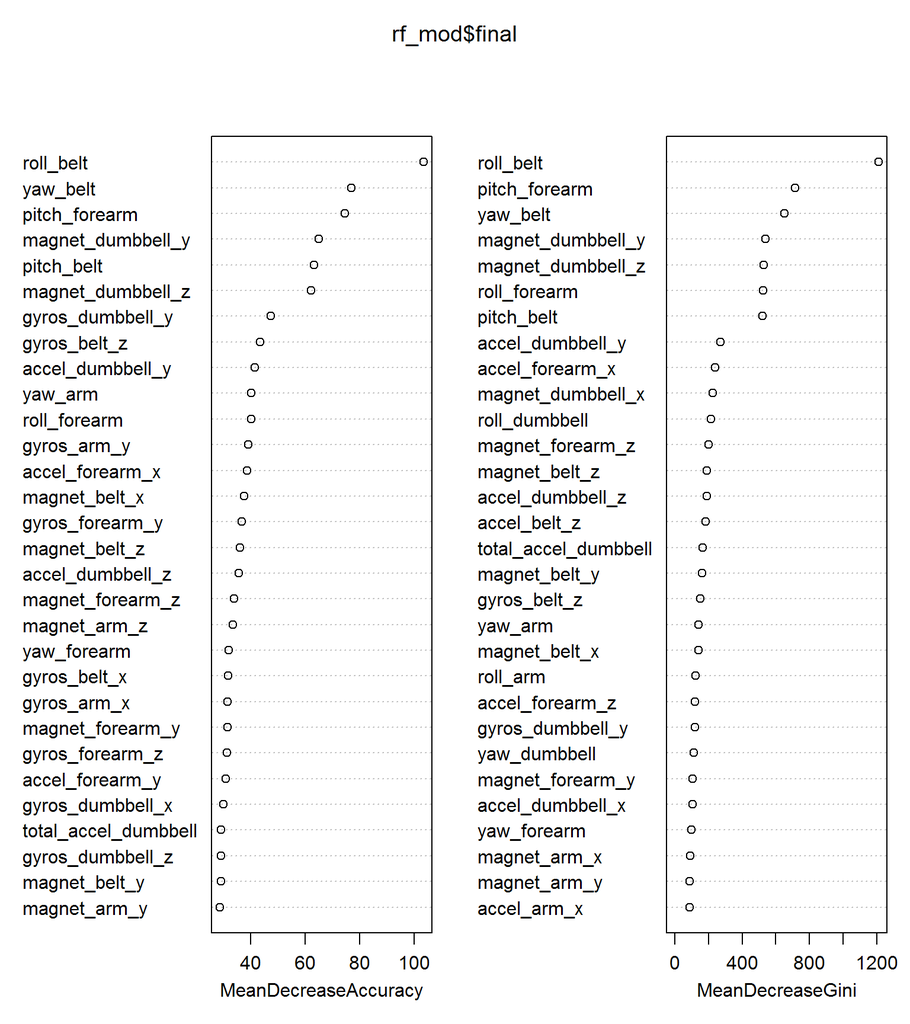

we see that the most important variables for the model are roll_belt, yaw_belt, pitch_forearm, magnet_dumbbell_y, pitch_belt, magnet_dumbbelt and roll_forearm.